# Assignment

William Li

2023-02-17

## 1. Load and check data (5pt)

You first task is to do a very simple data check:

1. (1pt) For solving the problems, and answering the questions, create a new rmarkdown document with an appropriate title. See https://faculty.washington.edu/otoomet/info201-book/ r-markdown.html#r-markdown-rstudio-creating.
2. (2pt) Load data. How many rows/columns do we have?

```r
library(tidyverse)
gm <- read_delim("data/gapminder (1).csv.bz2")
nrow(gm)
```

```
## [1] 13055
```

```r
ncol(gm)
```

```
## [1] 25
```

3. (2pt) Print a small sample of data. Does it look OK?

```r
gm %>%
  head()
```

```
## # A tibble: 6 × 25
##   iso3  name  iso2  region sub-r…¹ inter…²  time total…³ ferti…⁴ lifeE…⁵ child…⁶
##   <chr> <chr> <chr> <chr>  <chr>   <chr>   <dbl>   <dbl>   <dbl>   <dbl>   <dbl>
## 1 ABW   Aruba AW    Ameri… Latin … Caribb…  1960   54211    4.82    65.7      NA
## 2 ABW   Aruba AW    Ameri… Latin … Caribb…  1961   55438    4.66    66.1      NA
## 3 ABW   Aruba AW    Ameri… Latin … Caribb…  1962   56225    4.47    66.4      NA
## 4 ABW   Aruba AW    Ameri… Latin … Caribb…  1963   56695    4.27    66.8      NA
## 5 ABW   Aruba AW    Ameri… Latin … Caribb…  1964   57032    4.06    67.1      NA
## 6 ABW   Aruba AW    Ameri… Latin … Caribb…  1965   57360    3.84    67.4      NA
## # … with 14 more variables: youthFemaleLiteracy <dbl>, youthMaleLiteracy <dbl>,
## #   adultLiteracy <dbl>, GDP_PC <dbl>, accessElectricity <dbl>,
## #   agriculturalLand <dbl>, agricultureTractors <dbl>, cerealProduction <dbl>,
## #   fertilizerHa <dbl>, co2 <dbl>, greenhouseGases <dbl>, co2_PC <dbl>,
## #   pm2.5_35 <dbl>, battleDeaths <dbl>, and abbreviated variable names
## #   ¹`sub-region`, ²`intermediate-region`, ³totalPopulation, ⁴fertilityRate,
## #   ⁵lifeExpectancy, ⁶childMortality
```

## 2. Descriptive statistics (15pt)

1. (3pt) How many countries are there in the dataset? Analyze all three: iso3, iso2 and name.

```r
gm %>%
  select(iso3) %>%
  unique() %>%
  count()
```

```
## # A tibble: 1 × 1
##       n
##   <int>
## 1   253
```

```r
gm %>%
  select(name) %>%
  unique() %>%
  count()
```

```
## # A tibble: 1 × 1
##       n
##   <int>
## 1   250
```

```r
gm %>%
  select(iso2) %>%
  unique() %>%
  count()
```

```
## # A tibble: 1 × 1
##       n
##   <int>
## 1   249
```

2. If you did this correctly, you saw that there are more names than iso-2 codes, and there are even more iso3 -codes. What is going on? Can you find it out?
1. (5pt) Find how many names are there for each iso-2 code. Are there any iso-2 codes that correspond to more than one name? What are these countries?

```r
gm %>%
  group_by(iso2, name) %>%
  summarize(name_num = n_distinct(name))
```

```
## # A tibble: 250 × 3
## # Groups:   iso2 [249]
##    iso2  name                 name_num
##    <chr> <chr>                   <int>
##  1 AD    Andorra                     1
##  2 AE    United Arab Emirates        1
##  3 AF    Afghanistan                 1
##  4 AG    Antigua and Barbuda         1
##  5 AI    Anguilla                    1
##  6 AL    Albania                     1
##  7 AM    Armenia                     1
##  8 AO    Angola                      1
##  9 AQ    Antarctica                  1
## 10 AR    Argentina                   1
## # … with 240 more rows
```

*iso2 code NA corresponds to two country names, one is Namiibia and another is a NA*

2. (5pt) Now repeat the same for name and iso3-code. Are there country names that have more than one iso3-code? What are these countries? Hint: two of these entitites are CHANISL and NLD CURACAO.

```r
gm %>%
  group_by(name, iso3) %>%
  summarize(num = n_distinct(iso3))
```

```
## # A tibble: 253 × 3
## # Groups:   name [250]
##    name                iso3    num
##    <chr>               <chr> <int>
##  1 Afghanistan         AFG       1
##  2 Albania             ALB       1
##  3 Algeria             DZA       1
##  4 American Samoa      ASM       1
##  5 Andorra             AND       1
##  6 Angola              AGO       1
##  7 Anguilla            AIA       1
##  8 Antarctica          ATA       1
##  9 Antigua and Barbuda ATG       1
## 10 Argentina           ARG       1
## # … with 243 more rows
```

*The “NA” names have more than one iso3-code. But I am not sure what does “What are these countries” mean since I didn’t find any names here rather than NA.*

3. (2pt) What is the minimum and maximum year in these data?

```r
min(gm$time, na.rm = TRUE)
```

```
## [1] 1960
```

```r
max(gm$time, na.rm = TRUE)
```

```
## [1] 2019
```

## 3. CO2 emissions (30pt)

Next, let’s analyze CO2 emissions.

1. (2pt) How many missing co2 emissions are there for each year? Analyze both missing CO2 and co2_PC. Which years have most missing data?

```r
gm %>%
  group_by(time) %>%
  summarize(missing = sum(is.na(co2)), missing_pc = sum(is.na(co2_PC)))
```

```
## # A tibble: 61 × 3
##     time missing missing_pc
##    <dbl>   <int>      <int>
##  1  1960      60         60
##  2  1961      60         60
##  3  1962      58         58
##  4  1963      57         57
##  5  1964      51         51
##  6  1965      51         51
##  7  1966      51         51
##  8  1967      51         51
##  9  1968      51         51
## 10  1969      51         51
## # … with 51 more rows
```

```r
gm %>%
  group_by(time) %>%
  summarize(missing = sum(is.na(co2)) + sum(is.na(co2_PC))) %>%
  arrange(desc(missing))
```

```
## # A tibble: 61 × 2
##     time missing
##    <dbl>   <int>
##  1  2017     434
##  2  2018     434
##  3  2019     434
##  4  1960     120
##  5  1961     120
##  6  1962     116
##  7  1963     114
##  8  1964     102
##  9  1965     102
## 10  1966     102
## # … with 51 more rows
```

*2017, 2018 and 2019 have the most missing data.*

2. (5pt) Make a plot of total CO2 emissions over time for the U.S, China, and India. Add a few more countries of your choice. Explain what do you see.

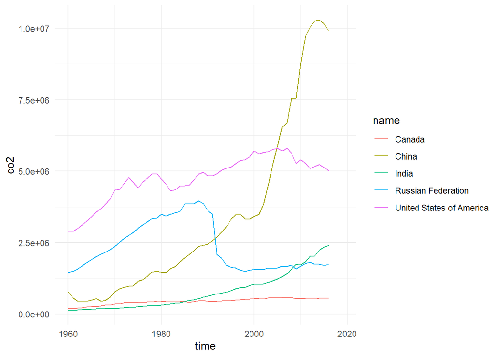

```r
target <- c("United States of America", "China", "India",
            "Russian Federation", "Canada")
gm %>%
  filter(name %in% target) %>%
  ggplot(aes(time, co2, col = name)) +
  geom_line() +
  theme_minimal()
```

3. (5pt) Now let’s analyze the CO2 emissions per capita (co2_PC ). Make a similar plot of the same countries. What does this figure suggest?

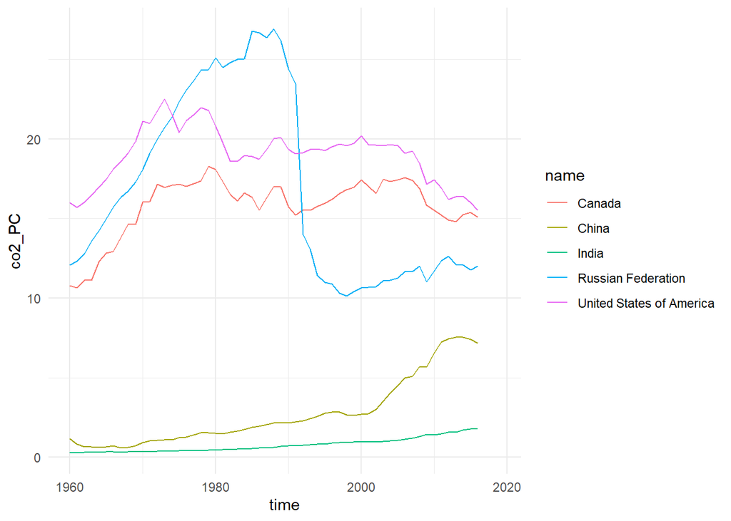

```r
gm %>%
  filter(name %in% target) %>%
  ggplot(aes(time, co2_PC, col = name)) +
  geom_line() +
  theme_minimal()
```

*This figure suggests that the per capita emissions are still relatively high in the US, Russia and Canada. But the overall trend looks like the same as before.*

4. (6pt) Compute average CO2 emissions per capita across the continents (assume region is the same as continent). Comment what do you see. Note: just compute averages over countries and ignore the fact that countries are of different size. Hint: Americas 2016 should be 4.80.

```r
ave <- gm %>%
  group_by(region, time) %>%
  summarize(average_co2 = mean(co2_PC, na.rm = TRUE)) %>%
  mutate(region = ifelse(region == "", NA, region)) %>%
  drop_na()
ave
```

```
## # A tibble: 285 × 3
## # Groups:   region [5]
##    region  time average_co2
##    <chr>  <dbl>       <dbl>
##  1 Africa  1960       0.291
##  2 Africa  1961       0.300
##  3 Africa  1962       0.299
##  4 Africa  1963       0.310
##  5 Africa  1964       0.349
##  6 Africa  1965       0.385
##  7 Africa  1966       0.422
##  8 Africa  1967       0.607
##  9 Africa  1968       0.781
## 10 Africa  1969       0.824
## # … with 275 more rows
```

5. (7pt) Make a barplot where you show the previous results–average CO2 emissions per capita across continents in 1960 and 2016.

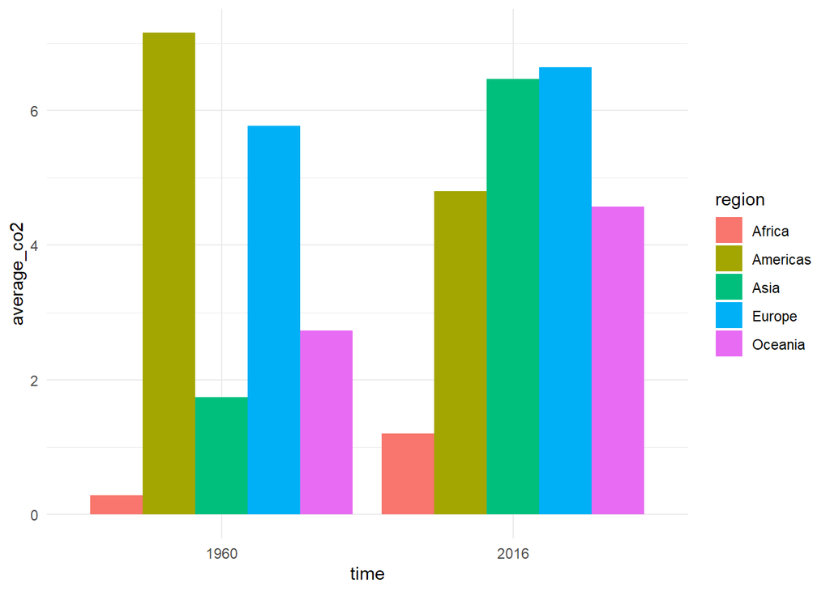

```r
ave %>%
  mutate(time = as.factor(time)) %>%
  filter(time %in% c(1960,2016)) %>%
  ggplot(aes(time, average_co2, fill=region)) +
  geom_bar(stat = "identity",position = "dodge") +
  theme_minimal()
```

6. Which countries are the three largest, and three smallest CO2 emitters (in terms of CO2 per capita) in 2019 for each continent? (Assume region is continent).

```r
largest <- gm %>%
  mutate(region = ifelse(region=="", NA, region)) %>%
  filter(time == 2016) %>%
  select(region, name, co2_PC) %>%
  drop_na() %>%
  group_by(region) %>%
  arrange(desc(co2_PC)) %>%
  top_n(3,co2_PC)
largest
```

```
## # A tibble: 15 × 3
## # Groups:   region [5]
##    region   name                     co2_PC
##    <chr>    <chr>                     <dbl>
##  1 Asia     Qatar                     38.9
##  2 Americas Trinidad and Tobago       31.8
##  3 Asia     Kuwait                    25.0
##  4 Asia     Bahrain                   22.2
##  5 Oceania  New Caledonia             19.3
##  6 Europe   Gibraltar                 18.8
##  7 Oceania  Australia                 15.5
##  8 Americas United States of America  15.5
##  9 Europe   Luxembourg                15.4
## 10 Americas Canada                    15.1
## 11 Europe   Faroe Islands             13.1
## 12 Oceania  Palau                     12.6
## 13 Africa   South Africa               8.48
## 14 Africa   Libya                      7.79
## 15 Africa   Seychelles                 6.39
```

```r
smallest <- gm %>%
  mutate(region = ifelse(region=="", NA, region)) %>%
  filter(time == 2016) %>%
  select(region, name, co2_PC) %>%
  drop_na() %>%
  group_by(region) %>%
  arrange(co2_PC) %>%
  top_n(3, co2_PC)
smallest
```

```
## # A tibble: 15 × 3
## # Groups:   region [5]
##    region   name                     co2_PC
##    <chr>    <chr>                     <dbl>
##  1 Africa   Seychelles                 6.39
##  2 Africa   Libya                      7.79
##  3 Africa   South Africa               8.48
##  4 Oceania  Palau                     12.6
##  5 Europe   Faroe Islands             13.1
##  6 Americas Canada                    15.1
##  7 Europe   Luxembourg                15.4
##  8 Americas United States of America  15.5
##  9 Oceania  Australia                 15.5
## 10 Europe   Gibraltar                 18.8
## 11 Oceania  New Caledonia             19.3
## 12 Asia     Bahrain                   22.2
## 13 Asia     Kuwait                    25.0
## 14 Americas Trinidad and Tobago       31.8
## 15 Asia     Qatar                     38.9
```

## 4. GDP per capita (50pt)

Let’s look at GDP per capita (GDP_PC ).

1. (8pt) Make a scatterplot of GDP per capita versus life expectancy by country, using data for 1960. Make the point size dependent on the country size, and color those according to the continent. Feel free to adjust the plot in other ways to make it better. Comment what do you see there.

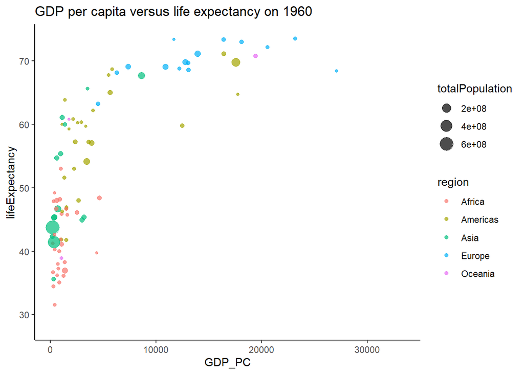

```r
p1 <- gm %>%
  filter(time == 1960, region!="") %>%
  ggplot(aes(GDP_PC, lifeExpectancy, size = totalPopulation, col = region)) +
  geom_point(alpha=0.7) +
  theme_classic() +
  labs(title = "GDP per capita versus life expectancy on 1960")
p1
```

2. (4pt) Make a similar plot, but this time use 2019 data only.

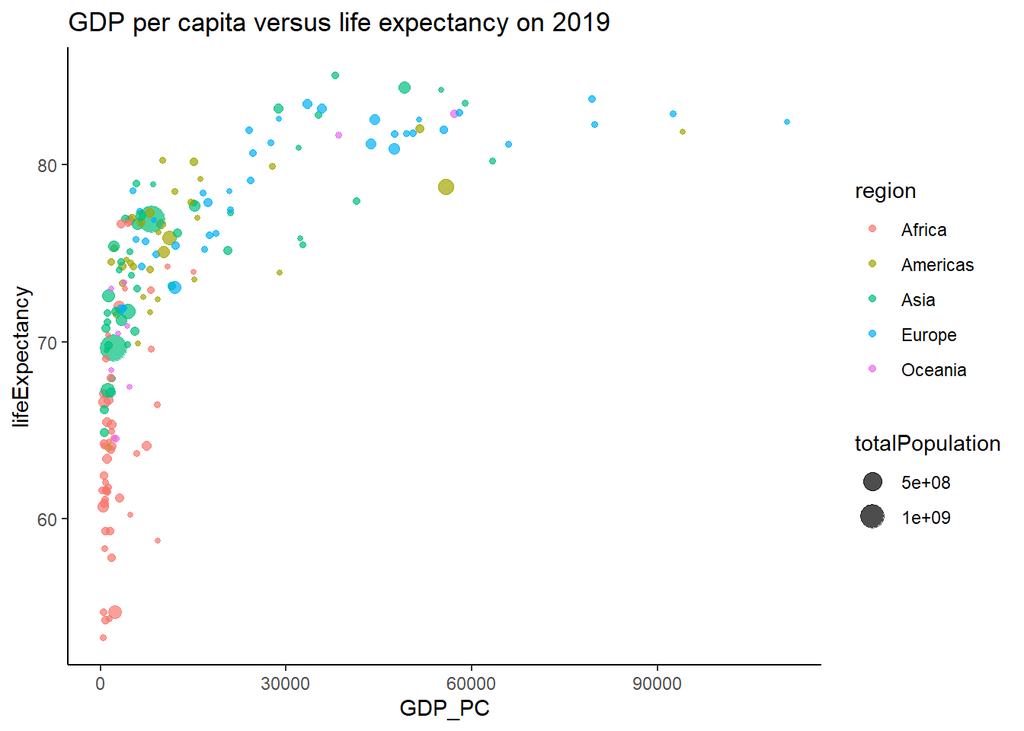

```r
p2 <- gm %>%
  filter(time == 2019, region!="") %>%
  ggplot(aes(GDP_PC, lifeExpectancy, size=totalPopulation, col=region)) +
  geom_point(alpha=0.7) +
  theme_classic() +
  labs(title = "GDP per capita versus life expectancy on 2019")
p2
```

3. (6pt) Compare these two plots and comment what do you see. How has world developed through the last 60 years?

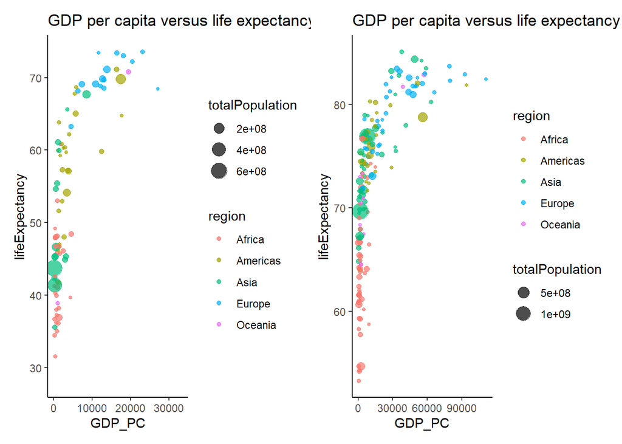

```r
library(patchwork)
p1 + p2
```